# Beta binomial

Peter Ralph

November 15, 2018

We flip an odd-looking coin 100 times, and get 65 heads. What is it’s “true” probability of heads?

*What do we mean, “true”?* The *long-run* proportion of heads that you’d get if you flipped the coin a lot of times.

*What prior should we use?* Coins are probably *close* to fair (else they wouldn’t look like coins), so let’s take a Beta(10,10), which allows the probability to differ from 50% by about 10%.

*Does it seem reasonable that $\theta = 1/2$?*

We know that the posterior distribution of $\theta$, given the data (100 flips and 65 heads) is Beta(75, 45).  
What this means is: suppose we have a big bag full of coins in which the distribution of “probabilities” is Beta(10,10). Then we flip *every* coin 100 times, but then put in a separate bag only those coins that got exactly 65 Heads (so, we *condition* on getting 65 heads). The math we did tells us that the distribution of probabilities for the coins in that new bag is Beta(75, 45).

Let’s look at that distribution, both using math and simulation:

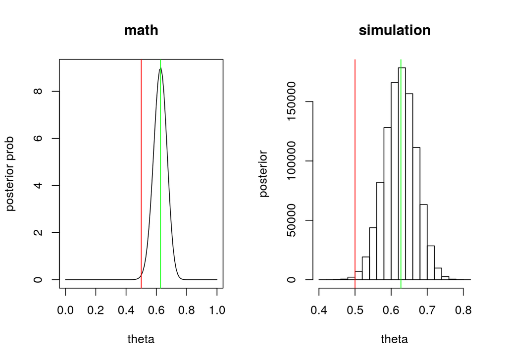

```r
layout(t(1:2))
curve(dbeta(x, shape1=75, shape2=45), from=0, to=1,
      xlab="theta", ylab="posterior prob", main="math")
abline(v=1/2, col='red')
abline(v=(75 - 1)/(75 + 45 - 2), col='green')

random_thetas <- rbeta(1e6, shape1=75, shape2=45)
hist(random_thetas, xlab="theta", ylab="posterior", main="simulation")
abline(v=1/2, col='red')
abline(v=(75 - 1)/(75 + 45 - 2), col='green')
```

It doesn’t look likely that the coin has $\theta = 1/2$: the posterior probability that $\theta \le 1/2$ is only 0.0028634.

*What is our best guess at $\theta$?*

The posterior mode of $\theta$ is 0.6271186, which we have added as a green line to the plot above.

*How far off are we?*

We can quantify how far off we’re likely to be with a 95% *credible interval*; we’ll use the “highest density interval” (because that is the narrowest 95% credible interval).

```r
library(HDInterval)
credible_interval <- hdi(rbeta(1e6, 75, 45), credMass=0.95)
```

Our 95% credible interval for the true proportion of the time that this coin comes up heads is from 0.5380757 to 0.7103241.